# Задание 1

$$Recall=\frac{TP}{TP+FN}=\frac{C(F_{s}F_{r})}{C(F_{s}F_{r})+C(L_{s}F_{r})}$$$$Precision= \frac{TP}{TP+FP*q}=\frac{C(F_{s}F_{r})}{C(F_{s}F_{r})+C(F_{s}L_{r})*q}$$

Где С() количество таких транзакций

Портируем нужные библиотеки

```python
import matplotlib.pyplot as plt
import random
import csv
```

Готовим данные для анализа,считывая файл и создавая массив с нужными нам данными

```python
def data_mining(file_name):
    with open(file_name) as file:
        #считываем файл получая массив строк,удаляем пустую последнюю
        csv = file.read().split('\n')
        csv.pop()
        #в этой строке выдавало ошибку при считывании из-за нехватки данных
        csv.pop(12313)

        tmp = [j for j in csv.pop(0).split(';')]
        AMOUNT,p1,p2,p3,p4,p5,CLASS=4,25,26,27,28,29,30
        data = [[tmp[AMOUNT],tmp[p1],tmp[p2],tmp[p3],tmp[p4],tmp[p5],tmp[CLASS]]]

        for i in csv:
            tmp = [j for j in i.split(';')]
            tmp = [tmp[AMOUNT],tmp[p1],tmp[p2],tmp[p3],tmp[p4],tmp[p5],tmp[CLASS]]
            data.append(tmp)
        return data
```

```python
data = data_mining('выгрузка.csv')
```

```python
print('Размер данных=',len(data))
```

```
Размер данных= 29304
```

Теперь будем высчитывать полноту и точность

```python
def recall_precision(data,cut_off=0.5,q=10):
        answer= [['TPR(recall)','precision','FPR']]
        for i in range(1,6):
            TP = 0
            FN = 0
            TN = 0
            FP = 0
            for j in range(1,len(data)):
                if (float(data[j][i])>=cut_off) and (str(data[j][6])=='F'):
                    TP+=1
                elif (float(data[j][i])>=cut_off) and (str(data[j][6])=='G'):
                    FP+=1
                elif (float(data[j][i])<cut_off) and (str(data[j][6])=='G'):
                    TN+=1
                elif (float(data[j][i])<cut_off) and (str(data[j][6])=='F'):
                    FN+=1
            try:
                recall=TP/(TP+FN)
            except ZeroDivisionError:
                recall='0'
            try:
                precision=TP/(TP+FP*q)
            except ZeroDivisionError:
                precision='0'
            try:
                FPR=FP/(FP+TN)
            except ZeroDivisionError:
                FPR='0'
            answer.append([recall,precision,FPR])


        return answer
```

Получаем данные и выводим их

```python
answer_d={}
cut_off_mass = [i/100 for i in range(1,100)]
for cut_off in cut_off_mass:
    answer_d[cut_off]=recall_precision(data,cut_off,q=10)
```

```python
for cut_off in [0.1,0.2,0.3,0.4,0.5,0.6,0.7,0.8,0.9,0.95,0.99]:
    print('cut_off=',cut_off,'\n',answer_d[cut_off],'\n')
```

```
cut_off= 0.1
 [['TPR(recall)', 'precision', 'FPR'], [0.9791623470868754, 0.05749505402526252, 0.8096532970768185], [1.0, 0.0480196738286306, 1.0], [0.9781256479369687, 0.05705560426934357, 0.8154055326047168], [1.0, 0.0480196738286306, 1.0], [0.9810284055567075, 0.056132587508823543, 0.832087015635622]]

cut_off= 0.2
 [['TPR(recall)', 'precision', 'FPR'], [0.8959154053493676, 0.05967737480319311, 0.7120744653035611], [0.9831018038565208, 0.05624455080870447, 0.832087015635622], [0.9569769852788721, 0.06560720961471489, 0.6874967316843591], [1.0, 0.04802445533118254, 0.9998954138994928], [0.9634045200082936, 0.06…

cut_off= 0.3
 [['TPR(recall)', 'precision', 'FPR'], [0.7490151358075886, 0.05964419862137285, 0.5956701354390002], [0.9197594857972217, 0.0654074696627888, 0.6629189980651572], [0.9362430022807381, 0.07625537232650235, 0.5720859697746169], [0.9478540327596932, 0.06592733067499261, 0.6774041729854102], [0.9478540…

cut_off= 0.4
 [['TPR(recall)', 'precision', 'FPR'], [0.5844909807173958, 0.06205970412116943, 0.445589081211107], [0.8557951482479784, 0.07109943585547565, 0.5639805469853056], [0.9002695417789758, 0.09108071824131565, 0.4531715734978821], [0.8178519593613933, 0.0786548220819749, 0.4832400773937144], [0.91727140…

cut_off= 0.5
 [['TPR(recall)', 'precision', 'FPR'], [0.2737922454903587, 0.03400677302635815, 0.39230246300266697], [0.7220609579100146, 0.07834205050334626, 0.4284892537781729], [0.8440804478540328, 0.11899681389026921, 0.31522250692882914], [0.5566037735849056, 0.07542955085067225, 0.34414056371908175], [0.868…

cut_off= 0.6
 [['TPR(recall)', 'precision', 'FPR'], [0.262699564586357, 0.03709885219020848, 0.34393139151806723], [0.6425461331121709, 0.07631313255682239, 0.39230246300266697], [0.7660170018660585, 1.0, 0.0], [0.04281567489114659, 0.05725772910023569, 0.03555927417246248], [0.8178519593613933, 0.07866266489844…

cut_off= 0.7
 [['TPR(recall)', 'precision', 'FPR'], [0.0011403690648973668, 0.18032786885245902, 0.0002614652512681065], [0.5578478125647937, 0.07562788998046409, 0.34393139151806723], [0.6660792038150529, 1.0, 0.0], [0.04271200497615592, 0.05720633157456262, 0.03550698112220886], [0.7133526850507983, 0.07766278…

cut_off= 0.8
 [['TPR(recall)', 'precision', 'FPR'], [0.0, '0', 0.0], [0.0025917478747667427, 0.3333333333333333, 0.0002614652512681065], [0.5757827078581795, 1.0, 0.0], [0.04250466514617458, 0.05694444444444444, 0.03550698112220886], [0.6376736471076093, 0.07577829520395216, 0.39230246300266697]]

cut_off= 0.9
 [['TPR(recall)', 'precision', 'FPR'], [0.0, '0', 0.0], [0.0, '0', 0.0], [0.29421521874352063, 1.0, 0.0], [0.04250466514617458, 0.057103064066852366, 0.035402395021701616], [0.5562927638399336, 0.07543297345928925, 0.34393139151806723]]

cut_off= 0.95
 [['TPR(recall)', 'precision', 'FPR'], [0.0, '0', 0.0], [0.0, '0', 0.0], [0.0, '0', 0.0], [0.04105328633630521, 0.05852793378657996, 0.03331067301155676], [0.4713871034625752, 0.0749007527962179, 0.29367777022433716]]

cut_off= 0.99
 [['TPR(recall)', 'precision', 'FPR'], [0.0, '0', 0.0], [0.0, '0', 0.0], [0.0, '0', 0.0], [0.016794526228488493, 0.07706945765937202, 0.010144851749202531], [0.295355587808418, 0.09169912131063118, 0.14757098781571928]]
```

# Задание 2

$$Recall=\frac{TP}{TP+FN}=\frac{S(F_{s}F_{r})}{S(F_{s}F_{r})+S(L_{s}F_{r})}$$$$Precision= \frac{TP}{TP+FP*q}=\frac{S(F_{s}F_{r})}{S(F_{s}F_{r})+S(F_{s}L_{r})*q}$$

Где S()-сумма таких транзакций

```python
def recall_precision_money(data,cut_off=0.5,q=10):
        answer=[['TPR(recall_m)','precision_m','FPT_m']]

        for i in range(1,6):
            TP = 0
            FN = 0
            TN = 0
            FP = 0
            for j in range(1,len(data)):
                if data[j][0] != '':
                    sum = float(data[j][0])
                if (float(data[j][i])>=cut_off) and (str(data[j][6])=='F'):
                    TP+=sum
                elif (float(data[j][i])>=cut_off) and (str(data[j][6])=='G'):
                    FP+=sum
                elif (not(float(data[j][i])>=cut_off)) and (str(data[j][6])=='G'):
                    TN+=sum
                elif (not(float(data[j][i])>=cut_off)) and (str(data[j][6])=='F'):
                    FN+=sum
            try:
                recall=TP/(TP+FN)
            except ZeroDivisionError:
                recall='0'
            try:
                precision=TP/(TP+FP*q)
            except ZeroDivisionError:
                precision='0'
            try:
                FPR=FP/(FP+TN)
            except ZeroDivisionError:
                FPR='0'
            answer.append([recall,precision,FPR])

        return answer
```

Получаем данные и выводим их

```python
answer_m_d= {}
cut_off_mass_m = [i/100 for i in range(1,100)]
for cut_off in cut_off_mass_m:
    answer_m_d[cut_off] = recall_precision_money(data,cut_off,q=10)
```

```python
for cut_off in [0.1,0.2,0.3,0.4,0.5,0.6,0.7,0.8,0.9,0.95,0.99]:
    print('cut_off=',cut_off,'\n',answer_m_d[cut_off],'\n')
```

```
cut_off= 0.1
 [['TPR(recall_m)', 'precision_m', 'FPT_m'], [0.9611527195431848, 0.0517687399162424, 0.7568764547592146], [1.0, 0.041219717940729914, 1.0], [0.9606739435808853, 0.05089141572953319, 0.7702528290603144], [1.0, 0.041219717940729914, 1.0], [0.9638613317244922, 0.048385072232333175, 0.8149863439192119]…

cut_off= 0.2
 [['TPR(recall_m)', 'precision_m', 'FPT_m'], [0.81678517285839, 0.06041458963137132, 0.5461201512219054], [0.9656096581162038, 0.04846858300111809, 0.8149863439192119], [0.9238082226019778, 0.06695580078097256, 0.5534542846049282], [1.0, 0.041220055811897124, 0.9999914508396527], [0.9302527728191226…

cut_off= 0.3
 [['TPR(recall_m)', 'precision_m', 'FPT_m'], [0.6189048533047601, 0.05964233841460968, 0.4195156963721876], [0.8516494433240163, 0.0648191696490183, 0.5282492890893146], [0.8749234169356489, 0.08348051857226926, 0.4129643145696993], [0.8916700362364741, 0.07034261582601017, 0.5066342002374059], [0.8…

cut_off= 0.4
 [['TPR(recall_m)', 'precision_m', 'FPT_m'], [0.34471347110995054, 0.05187538762728368, 0.27086210111327846], [0.7598642724511975, 0.07666833017248294, 0.3934265589358551], [0.7919630260554712, 0.10285594827974293, 0.29697753463835047], [0.6903488899476272, 0.09138489486672956, 0.29509380238843735],…

cut_off= 0.5
 [['TPR(recall_m)', 'precision_m', 'FPT_m'], [0.1348273674362985, 0.02403058062238027, 0.23541597068415349], [0.5465374534411631, 0.08320895524603808, 0.2588845565861145], [0.717569574592336, 0.14478836285667895, 0.1822174153515674], [0.312259479151668, 0.06253526150189806, 0.20124797715517181], [0.…

cut_off= 0.6
 [['TPR(recall_m)', 'precision_m', 'FPT_m'], [0.11307674671142583, 0.023596050277863323, 0.20116361963201562], [0.434196753188775, 0.07346780833548236, 0.23541597068415349], [0.6084096745609308, 1.0, 0.0], [0.03787087552239329, 0.035698721221001234, 0.0439796076495234], [0.6903488899476272, 0.091386…

cut_off= 0.7
 [['TPR(recall_m)', 'precision_m', 'FPT_m'], [0.0018586225324483995, 0.24380738731218699, 0.0002478350289716023], [0.31318994719993015, 0.06273456555005226, 0.20116361963201562], [0.4490645715358533, 1.0, 0.0], [0.037858944194215455, 0.03569657442302823, 0.04396849374107192], [0.5262536972468168, 0.…

cut_off= 0.8
 [['TPR(recall_m)', 'precision_m', 'FPT_m'], [0.0, '0', 0.0], [0.011966000378888007, 0.6748746307900155, 0.0002478350289716023], [0.34316834999218326, 1.0, 0.0], [0.03783766665896499, 0.03567722795078604, 0.04396849374107192], [0.4204670946216958, 0.07131035777768041, 0.23541597068415349]]

cut_off= 0.9
 [['TPR(recall_m)', 'precision_m', 'FPT_m'], [0.0, '0', 0.0], [0.0, '0', 0.0], [0.13999321541806564, 1.0, 0.0], [0.03783766665896499, 0.03572926360440266, 0.04390208945464508], [0.31222627028823974, 0.06255360788775319, 0.20116361963201562]]

cut_off= 0.95
 [['TPR(recall_m)', 'precision_m', 'FPT_m'], [0.0, '0', 0.0], [0.0, '0', 0.0], [0.0, '0', 0.0], [0.035015859779824444, 0.03528871987344086, 0.04115401093319049], [0.24647270069535948, 0.061620736996022635, 0.16136385444766513]]

cut_off= 0.99
 [['TPR(recall_m)', 'precision_m', 'FPT_m'], [0.0, '0', 0.0], [0.0, '0', 0.0], [0.0, '0', 0.0], [0.010699098823644799, 0.03276641468416771, 0.013577992535037667], [0.14091886376653923, 0.06613375958093261, 0.08554931138239481]]
```

# Задание 3

## ROC из 1 задания

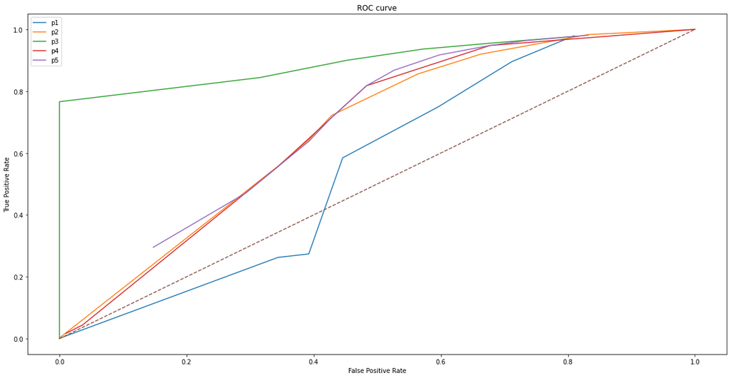

```python
FPR=[[]for i in range(5)]
TPR=[[]for i in range(5)]
for i in range(1,6):
    for cut_off in [0.1,0.2,0.3,0.4,0.5,0.6,0.7,0.8,0.9,0.95,0.99]:
        FPR[i-1].append(float(answer_d[cut_off][i][2]))
        TPR[i-1].append(float(answer_d[cut_off][i][0]))

plt.gcf().clear()
plt.figure(figsize=(20,10))
plt.title('ROC curve')
plt.plot(FPR[0], TPR[0], label='p1')
plt.plot(FPR[1], TPR[1], label='p2')
plt.plot(FPR[2], TPR[2], label='p3')
plt.plot(FPR[3], TPR[3], label='p4')
plt.plot(FPR[4], TPR[4], label='p5')
plt.plot([0, 1], [0, 1], '--')
plt.ylabel('True Positive Rate')
plt.xlabel('False Positive Rate')
plt.legend()
plt.show()
```

## ROC_m из 2 задания

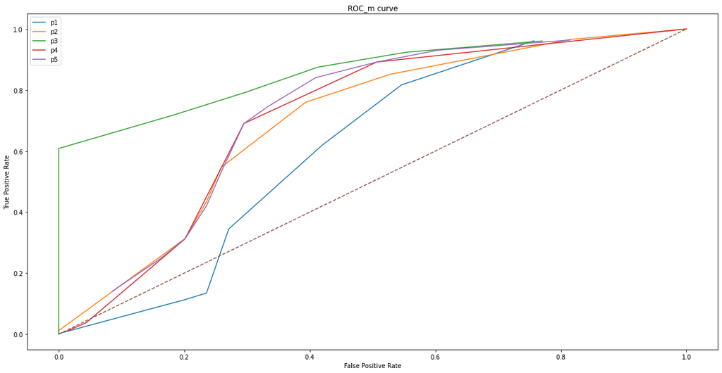

```python
FPR_m=[[]for i in range(5)]
TPR_m=[[]for i in range(5)]
for i in range(1,6):
    for cut_off in [0.1,0.2,0.3,0.4,0.5,0.6,0.7,0.8,0.9,0.95,0.99]:
        FPR_m[i-1].append(float(answer_m_d[cut_off][i][2]))
        TPR_m[i-1].append(float(answer_m_d[cut_off][i][0]))

plt.gcf().clear()
plt.figure(figsize=(20,10))
plt.title('ROC_m curve')
plt.plot(FPR_m[0], TPR_m[0], label='p1')
plt.plot(FPR_m[1], TPR_m[1], label='p2')
plt.plot(FPR_m[2], TPR_m[2], label='p3')
plt.plot(FPR_m[3], TPR_m[3], label='p4')
plt.plot(FPR_m[4], TPR_m[4], label='p5')
plt.plot([0, 1], [0, 1], '--')
plt.ylabel('True Positive Rate')
plt.xlabel('False Positive Rate')
plt.legend()
plt.show()
```

# Задание 4

## ROC из 1 задания

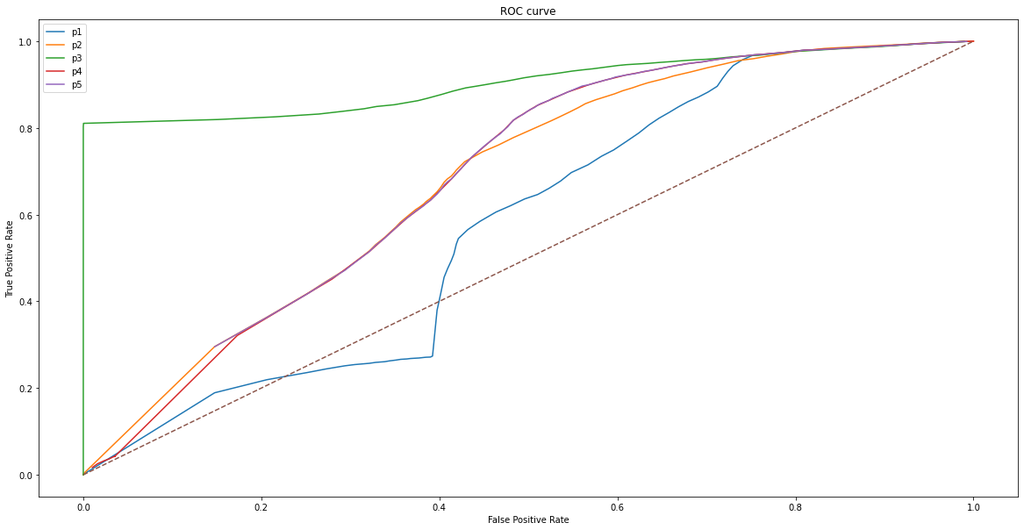

```python
FPR=[[]for i in range(5)]
TPR=[[]for i in range(5)]
cut_off_mass = [i/100 for i in range(1,100)]
for i in range(1,6):
    for cut_off in cut_off_mass:
        FPR[i-1].append(float(answer_d[cut_off][i][2]))
        TPR[i-1].append(float(answer_d[cut_off][i][0]))

plt.gcf().clear()
plt.figure(figsize=(20,10))
plt.title('ROC curve')
plt.plot(FPR[0], TPR[0], label='p1')
plt.plot(FPR[1], TPR[1], label='p2')
plt.plot(FPR[2], TPR[2], label='p3')
plt.plot(FPR[3], TPR[3], label='p4')
plt.plot(FPR[4], TPR[4], label='p5')
plt.plot([0, 1], [0, 1], '--')
plt.ylabel('True Positive Rate')
plt.xlabel('False Positive Rate')
plt.legend()
plt.show()
```

## ROC_m из 2 задания

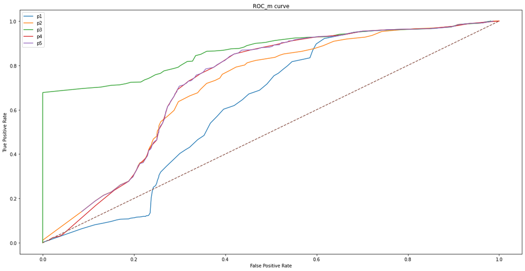

```python
FPR_m=[[]for i in range(5)]
TPR_m=[[]for i in range(5)]
cut_off_mass_m = [i/100 for i in range(1,100)]
for i in range(1,6):
    for cut_off in cut_off_mass_m:
        FPR_m[i-1].append(float(answer_m_d[cut_off][i][2]))
        TPR_m[i-1].append(float(answer_m_d[cut_off][i][0]))

plt.gcf().clear()
plt.figure(figsize=(20,10))
plt.title('ROC_m curve')
plt.plot(FPR_m[0], TPR_m[0], label='p1')
plt.plot(FPR_m[1], TPR_m[1], label='p2')
plt.plot(FPR_m[2], TPR_m[2], label='p3')
plt.plot(FPR_m[3], TPR_m[3], label='p4')
plt.plot(FPR_m[4], TPR_m[4], label='p5')
plt.plot([0, 1], [0, 1], '--')
plt.ylabel('True Positive Rate')
plt.xlabel('False Positive Rate')
plt.legend()
plt.show()
```

# Задание 5

## Precision-recall

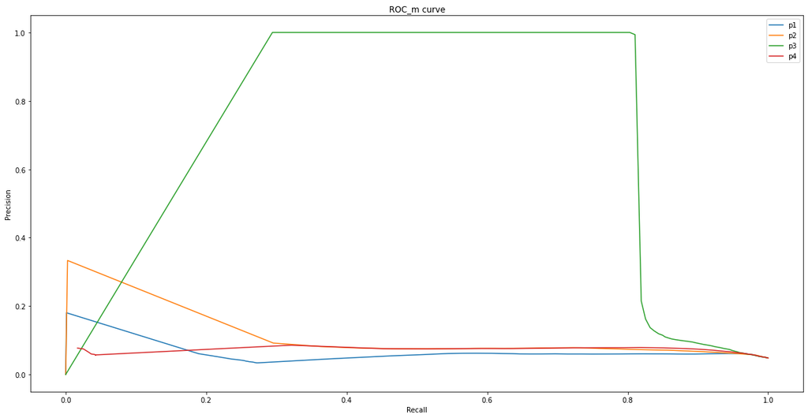

```python
recall=[[]for i in range(5)]
precs=[[]for i in range(5)]
cut_off_mass = [i/100 for i in range(1,100)]
for i in range(1,6):
    for cut_off in cut_off_mass_m:
        recall[i-1].append(float(answer_d[cut_off][i][0]))
        precs[i-1].append(float(answer_d[cut_off][i][1]))

plt.gcf().clear()
plt.figure(figsize=(20,10))
plt.title('ROC_m curve')
plt.plot(recall[0], precs[0], label='p1')
plt.plot(recall[1], precs[1], label='p2')
plt.plot(recall[2], precs[2], label='p3')
plt.plot(recall[3], precs[3], label='p4')
plt.ylabel('Precision')
plt.xlabel('Recall')
plt.legend()
plt.show()
```

# Задание 6

Записываем данные из 5 заданий

```python
with open('DATA/data.csv', 'w') as file:
    writer = csv.writer(file,delimiter=';',lineterminator='\n')
    writer.writerows(data)

cut_off_mass = [i/100 for i in range(1,100)]
with open('DATA/answer_d.csv', 'w') as file:
    writer = csv.writer(file,delimiter=';',lineterminator='\n')
    for cut_off in cut_off_mass:
        tmp = [[cut_off]]
        writer.writerows(tmp)
        writer.writerows(answer_d[cut_off])

with open('DATA/ROC.csv', 'w') as file:
    writer = csv.writer(file,delimiter=';',lineterminator='\n')
    writer.writerows([['X_FPR']])
    writer.writerows(FPR)
    writer.writerows([['Y_TPR']])
    writer.writerows(TPR)

with open('DATA/ROC_M.csv', 'w') as file:
    writer = csv.writer(file,delimiter=';',lineterminator='\n')
    writer.writerows([['X_FPR_M']])
    writer.writerows(FPR_m)
    writer.writerows([['Y_TPR_M']])
    writer.writerows(TPR_m)

with open('DATA/Precision-recall.csv', 'w') as file:
    writer = csv.writer(file,delimiter=';',lineterminator='\n')
    writer.writerows([['X_recall']])
    writer.writerows(recall)
    writer.writerows([['Y_precision']])
    writer.writerows(precs)
```

# Задание 7

Делаем ансамбль $$p=\frac{A*p1+B*p2+C*p3}{A+B+C} $$

```python
data_ans = [['AMOUNT','p_fraud','CLASS']]
a = 0
b = 0.01
c = 0.99
for i in range(1,len(data)):
    p = (a*float(data[i][1])+b*float(data[i][2])+c*float(data[i][3]))/(a+b+c)
    data_ans.append([data[i][0],p,data[i][6]])
```

```python
def recall_precision_ans(data,cut_off=0.5,q=10):
        answer= [['TPR(recall)_ans','precision_ans','FPR_ans']]
        for i in [1]:
            TP = 0
            FN = 0
            TN = 0
            FP = 0
            for j in range(1,len(data)):
                if (float(data[j][i])>=cut_off) and (str(data[j][2])=='F'):
                    TP+=1
                elif (float(data[j][i])>=cut_off) and (str(data[j][2])=='G'):
                    FP+=1
                elif (float(data[j][i])<cut_off) and (str(data[j][2])=='G'):
                    TN+=1
                elif (float(data[j][i])<cut_off) and (str(data[j][2])=='F'):
                    FN+=1
            try:
                recall=TP/(TP+FN)
            except ZeroDivisionError:
                recall='0'
            try:
                precision=TP/(TP+FP*q)
            except ZeroDivisionError:
                precision='0'
            try:
                FPR=FP/(FP+TN)
            except ZeroDivisionError:
                FPR='0'
            answer.append([recall,precision,FPR])


        return answer
```

```python
answer_ans={}
cut_off_mass = [i/100 for i in range(1,100)]
for cut_off in cut_off_mass:
    answer_ans[cut_off]=recall_precision_ans(data_ans,cut_off,q=10)
```

```python
for cut_off in [0.1,0.2,0.3,0.4,0.5,0.6,0.7,0.8,0.9,0.95,0.99]:
    print('cut_off=',cut_off,'\n',answer_ans[cut_off],'\n')
```

```
cut_off= 0.1
 [['TPR(recall)_ans', 'precision_ans', 'FPR_ans'], [0.9782293178519593, 0.05696485275829178, 0.8168697380118183]]

cut_off= 0.2
 [['TPR(recall)_ans', 'precision_ans', 'FPR_ans'], [0.9573916649388348, 0.06551271592239208, 0.6888563509909533]]

cut_off= 0.3
 [['TPR(recall)_ans', 'precision_ans', 'FPR_ans'], [0.9367613518556914, 0.07615291262135922, 0.5732364168801967]]

cut_off= 0.4
 [['TPR(recall)_ans', 'precision_ans', 'FPR_ans'], [0.899232842629069, 0.0910904813912459, 0.4525963499450923]]

cut_off= 0.5
 [['TPR(recall)_ans', 'precision_ans', 'FPR_ans'], [0.8431474186191167, 0.11865544256889836, 0.31590231658212625]]

cut_off= 0.6
 [['TPR(recall)_ans', 'precision_ans', 'FPR_ans'], [0.7629069044163383, 1.0, 0.0]]

cut_off= 0.7
 [['TPR(recall)_ans', 'precision_ans', 'FPR_ans'], [0.6635911258552768, 1.0, 0.0]]

cut_off= 0.8
 [['TPR(recall)_ans', 'precision_ans', 'FPR_ans'], [0.5745386688782915, 1.0, 0.0]]

cut_off= 0.9
 [['TPR(recall)_ans', 'precision_ans', 'FPR_ans'], [0.18401409910843874, 1.0, 0.0]]

cut_off= 0.95
 [['TPR(recall)_ans', 'precision_ans', 'FPR_ans'], [0.0, '0', 0.0]]

cut_off= 0.99
 [['TPR(recall)_ans', 'precision_ans', 'FPR_ans'], [0.0, '0', 0.0]]
```

График

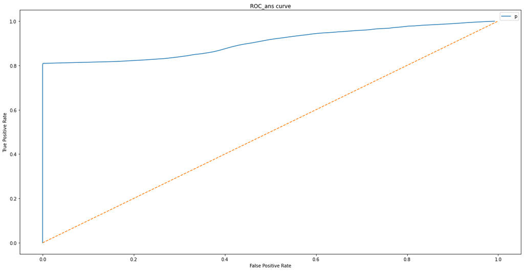

```python
FPR_ans=[]
TPR_ans=[]
cut_off_mas = [i/100 for i in range(1,100)]
for i in [1]:
    for cut_off in cut_off_mass:
        FPR_ans.append(float(answer_ans[cut_off][i][2]))
        TPR_ans.append(float(answer_ans[cut_off][i][0]))

plt.gcf().clear()
plt.figure(figsize=(20,10))
plt.title('ROC_ans curve')
plt.plot(FPR_ans, TPR_ans, label='p')
plt.plot([0, 1], [0, 1], '--')
plt.ylabel('True Positive Rate')
plt.xlabel('False Positive Rate')
plt.legend()
plt.show()
```

Коэффициент Джинни $$G=2AUC-1$$

```python
G = 0
AUC = 0
for i in range(0,len(cut_off_mass)-1):
    AUC += abs(FPR_ans[i]-FPR_ans[i+1])*(TPR_ans[i]+ TPR_ans[i+1])/2
G = 2*AUC-1
print('AUC=',AUC)
print('G=',G)
```

```
AUC= 0.8956699625022073
G= 0.7913399250044146
```

Эмпирическим путем было выяснено, что максимальный коэффицциент G= 0.7913399 получается при (0,0.01,0.99).Логично что система 3 является наилучшей среди трех, поэтому у нее наибольший вес, благодаря остальным системам с помощью маленьких весов мы вводим небольшую корректировку третей системе(так как на высоких FPR она не самая лучшая)

Миннимальнный коэффицциент G= 0.1331553 получается только при a,b,c=1,0,0 . Так как система 1 являлась наихуддшей среди трех. Тем самым добавляя веса второй и третьей системам мы только улуучшаем наш аннсамбль.

Насчет ннахождения максимального TPR ансамбля при FPR=0.1 .Так как из трех систем нашего ансамбля наилучше характеристики в этой точке имеет 3 система ,то при a,b,c=0,0,1 мы получим максимальный TPR при FPR=0.1 будет.

По графику мы примерно можем определить порог при котором третья система имеет FPR=0.1 Это чуть больше cut_off = 0.54